# House solar energy data analysis

Jason

2023-01-29

**Disclaimer**

All information provided in this website is based on personal experience and data available at the time of posting. Any inaccuracies are solely the responsibility of the author, and readers use the information on this website at their own risk.

# Background

**NOTE** This is a work in progress…

When we were researching solar panels for our house, we found lots of websites describing the general economics of it, such as this helpful [site](https://ca.renogy.com/blog/what-is-the-average-solar-panels-roi-in-canada/), but surprisingly, I could not find any websites/blogs describing real data from a household that had installed solar. What do the grid-energy consumption data look like before and after solar installation? What are the actual hourly / daily patterns of solar energy production and grid energy consumption for a household?

To fill this gap, I’ve decided to share our own data!

## Our household

We are two adults, two teenagers, and a dog occupying a 1.5 storey, 1260 ft$^{2}$ house in downtown Kelowna, British Columbia. Yeah, it’s a bit tight…

The house was build in the 1940s, so it’s as inefficient as you might expect. For instance, it still has wood chip insulation in most exterior walls. However, with the help of extremely handy members of the extended family, we’ve made some improvements that have definitely improved its efficiency.

We had new roof shingles and a ridge vent installed in December 2020 (leaking forced this), and I subsequently installed proper insulation and venting in the knee-walls next to the dormer bedrooms. That made a huge difference in the dormer rooms… much less hot in the summer, and much warmer in the winter.

In Spring 2022, we added a one-bedroom dwelling (500 ft$^{2}$) to the west side of the house, and decided this was an opportune time to install solar panels. The addition is very efficient; it has two small heat-pump units, one in the living room and one in the bedroom. It also has an electric fireplace for extra heat when needed (rarely).

Like many folks, we hope to replace our current vehicle with an EV some time in the next four or five years, so having our own energy source would help when the time comes.

We did not buy batteries for storing the solar power. One day maybe…

In November 2022 we replaced the remaining old, large windows on the main floor of our house. The house now feels much more air-tight! That’s the last of the home improvements for a while…

## Household energy consumption

Our typical annual household energy consumption was about 10,000 kWh. We’ll show the data for this in a bit…

We heat our house with an efficient gas furnace, so the laundry drier and electric stove/oven are probably the biggest consumers of electricity throughout the year. In the summer, air conditioning draws more. Of course we use A/C mostly when solar production should be greatest…

## The solar array

In the summer of 2022 we had an array of thirty-six 360W panels (model: Longi LR4-60HPB-360M) installed on our south-facing roof. The entire array size is 12.96kW.

Our solar system was supplied and installed by [Okanagan Solar](https://www.oksolarhomes.com). Their team was amazing to work with.

This system is large for our current needs (about 10,000 kWh / yr), but with the new one-bedroom addition, and hopefully an EV in the next few years, the 12.96kW solar system should be ideal.

The layout of the array on our roof is shown in the following images (provided by Okanagan Solar as part of their assessment):

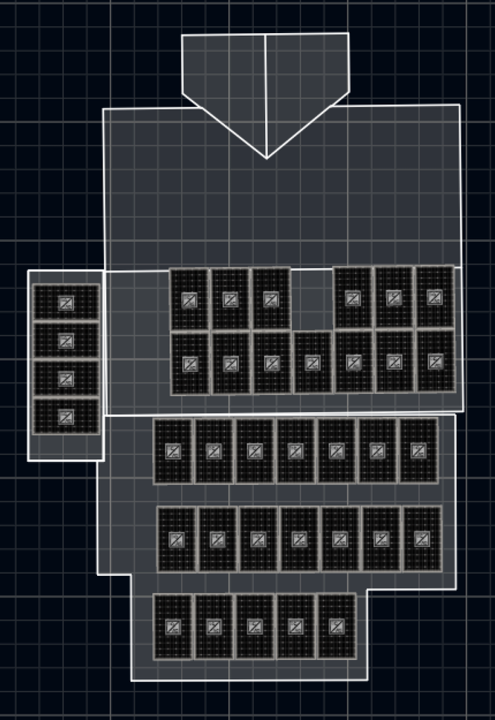

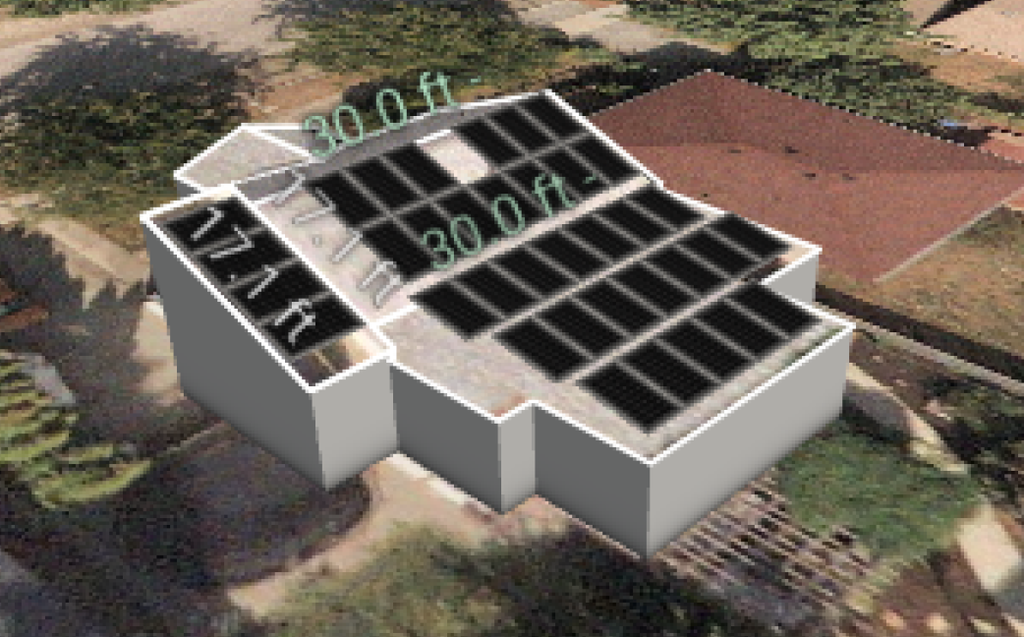

Note that the flatter part of the roof extends over our patio.

An added benefit of covering the south-facing roof with solar panels: the kids’ dormer bedrooms are even cooler in the summer, because the panels are intercepting the energy before they hit the roof tiles.

## Electricity supplier

Fortis BC is our electricity provider, and like most places in North America, we don’t have a choice about who we purchase electricity from.

As described at their [website](https://www.fortisbc.com/about-us/corporate-information/regulatory-affairs/our-electricity-utility/electric-bcuc-submissions/electricity-rates), Fortis bills customers bi-monthly, and uses a tiered charging system, such that the first 1600kWh are currently charged at $0.12365/kWh, and $0.13713 for any kWh beyond that. They also charge a flat service / delivery fee of about $40 for the two months.

Be sure to consult their website to keep track of any updates to rates.

**Net metering**

Fortis BC has a [net metering program](https://www.fortisbc.com/services/electricity-services/generating-your-own-electricity/net-metering), in which any energy produced by the solar array that is not used immediately on site is put back into the grid, and Fortis keeps track of this and “banks” the kWh on the account. In theory, Fortis then uses these banked amounts against future bills. However, I have yet to receive a bills that correctly reflect this, and their [website that explains a net-metering bill](https://www.fortisbc.com/services/electricity-services/generating-your-own-electricity/net-metering/understanding-your-net-metering-electricity-bill#item5) shows a new bill format that looks nothing like mine… I’ll update this website as soon as this is figured out.

If we happen to have anything left in our “bank” at the end of March, then our account will get credited at a rate equivalent to what Fortis pays their providers. This should be close to $0.10 / kWh. Given our cloudy winters, it’s unlikely we’ll have anything left in the bank in March.

## Power up!

We officially started producing solar power on July 8, 2022, and net metering started on July 15, 2022. So, between July 8 and July 15, the grid benefited from our solar output!

# The Data!

## Solar energy production data

I have another [script](https://github.com/pitherj/home_solar/blob/main/scripts/wrangle_solar_data.Rmd) that imports the raw solar energy data files, downloaded from the [AP Systems website](https://www.apsystemsema.com), and wrangles them into an appropriate (tidy) format.

Here’s what the first few rows of the resulting data table looks like:

```r
solar.data
```

```
## # A tibble: 2,548 × 4
##    date                day         hour    kWh
##    <dttm>              <date>     <dbl>  <dbl>
##  1 2022-07-08 04:00:00 2022-07-08     4  0.002
##  2 2022-07-08 05:00:00 2022-07-08     5  0.02
##  3 2022-07-08 06:00:00 2022-07-08     6  0.009
##  4 2022-07-08 07:00:00 2022-07-08     7  1.49
##  5 2022-07-08 08:00:00 2022-07-08     8  1.74
##  6 2022-07-08 09:00:00 2022-07-08     9  5.65
##  7 2022-07-08 10:00:00 2022-07-08    10  6.27
##  8 2022-07-08 11:00:00 2022-07-08    11  9.59
##  9 2022-07-08 12:00:00 2022-07-08    12 10.8
## 10 2022-07-08 13:00:00 2022-07-08    13 10.7
## # … with 2,538 more rows
```

Let’s visualize the data to check for errors:

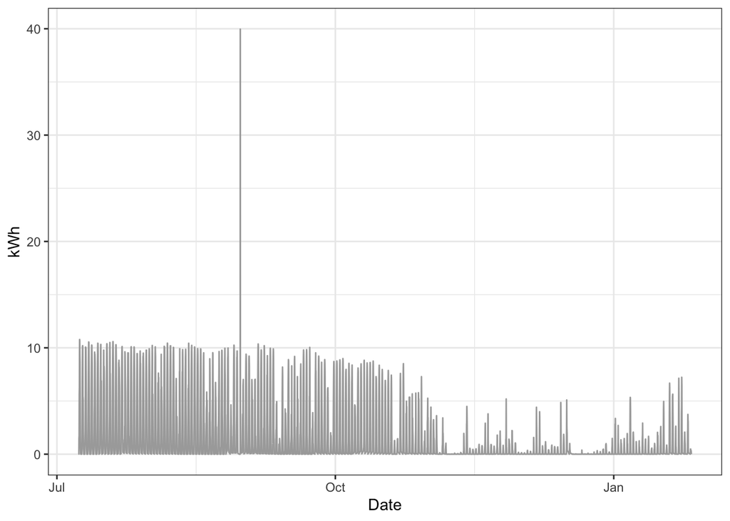

Figure 1: Hourly energy output (kWh) for the 36-panel solar array, starting July 8, 2022.

Ah, we see a strange data point… investigating, this is a morning when I took the datalogger offline. The system automatically sums up the total kWh produced over the time period that it was offline.

```
## # A tibble: 1 × 4
##   date                day         hour   kWh
##   <dttm>              <date>     <dbl> <dbl>
## 1 2022-08-30 14:00:00 2022-08-30    14  40.0
```

So for that day (August 30, 2022), we won’t be able to use the hourly data for analysis.

But we can sum up the total kWh by day, and plot:

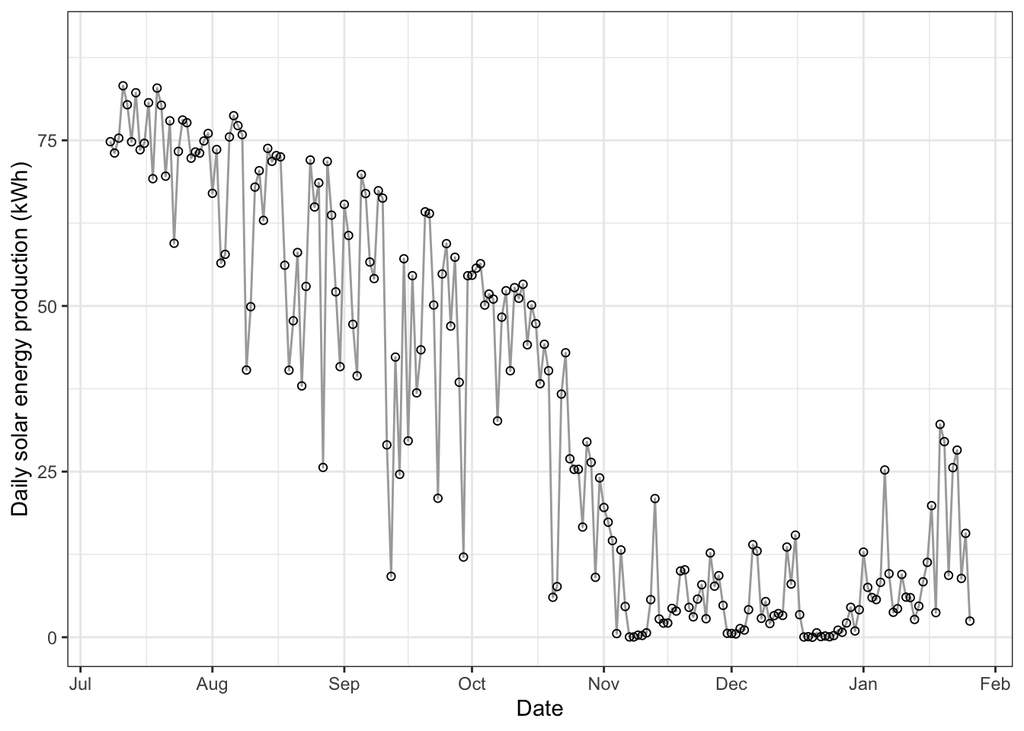

Figure 2: Daily energy output (kWh) for the 36-panel solar array, starting July 8, 2022.

And FYI, Kelowna got an early winter… beginning of November saw more than 30cm of snow fall, and it STAYED! Which meant that the solar panels were covered for the better part of 5 days. I then cleared off a few of them (the steeper angled ones), and we saw a wee bit of sun. However, from November through February each year, Kelowna tends to be very grey… the clouds settle in the valley and just stay here. But it’s often sunny at higher elevation.

In any case, we don’t anticipate generating much solar power between November and February…

## Grid energy consumption data

Another [script](https://github.com/pitherj/home_solar/blob/main/scripts/wrangle_electricity_data.Rmd) imports the raw Fortis energy consumption data for our account, downloaded from the FortisBC website, and wrangles them into an appropriate (tidy) format.

Unfortunately, I could only get historical consumption data back to June 1st, 2022.

Despite valiant efforts by a helpful Fortis customer service employee, Fortis was unable to provide me historical consumption data in any format that was readily usable. They’re working on improving this…

But I was provided a graph of 2 years of historical daily consumption data, and I’ll be attempting to extract the data from this graph in the coming weeks…

Here’s what the first few rows of the June 1st onward data look like:

```r
consumption.data
```

```
## # A tibble: 5,420 × 4
##    day         hour kw_returned kw_consumed
##    <date>     <dbl>       <dbl>       <dbl>
##  1 2022-06-01     0          NA       0.503
##  2 2022-06-01     1          NA       0.528
##  3 2022-06-01     2          NA       0.503
##  4 2022-06-01     3          NA       0.479
##  5 2022-06-01     4          NA       0.525
##  6 2022-06-01     5          NA       0.767
##  7 2022-06-01     6          NA       1.11
##  8 2022-06-01     7          NA       1.42
##  9 2022-06-01     8          NA       0.822
## 10 2022-06-01     9          NA       0.89
## # … with 5,410 more rows
```

Let’s visualize the data to check for errors:

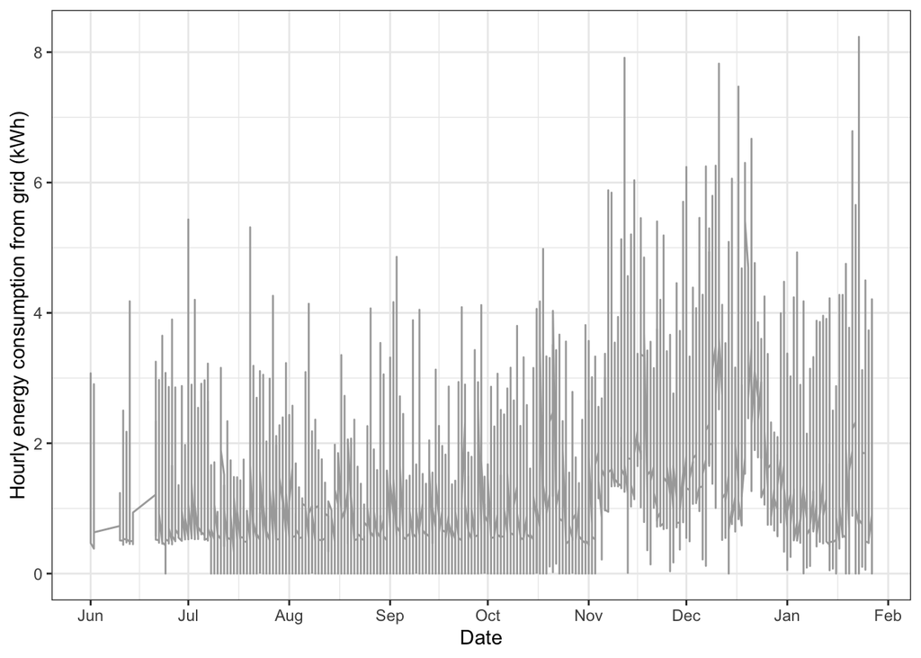

Figure 3: Hourly energy consumption (kWh) for our house, starting June 1, 2022.

hmm, that’s messy… but it does show that once the solar system was online (July 8), and during daytimes up to the end of October, we typically drew directly from solar, thus zero kWh consumed from the grid.

Let’s sum up the total kWh consumed by day, and visualize:

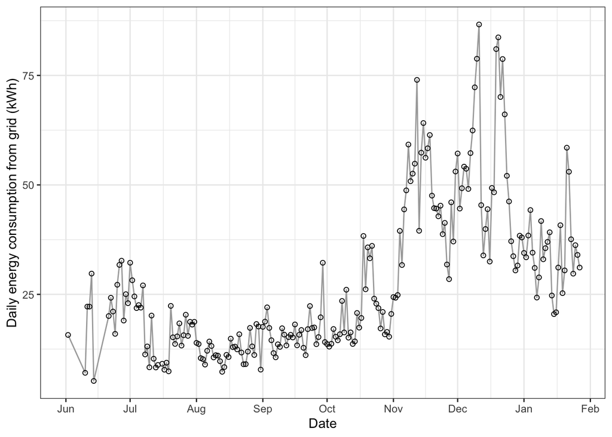

Figure 4: Daily energy consumption (kWh) for our house, starting June 1, 2022.

Note that the low consumption in June is due to data gaps, which are also a mystery to Fortis.

The substantial increase in energy consumption in November was from the combination of early winter/snow/cloud in Kelowna, and 3 weeks with our wonderfully handy in-laws living with us to do final upgrades at our house: replacing 4 windows and a door in the main house. So, over the first 3 weeks of November, we were using more electricity than usual, and we had little sun for solar energy production.

Let’s combine the data into one plot.

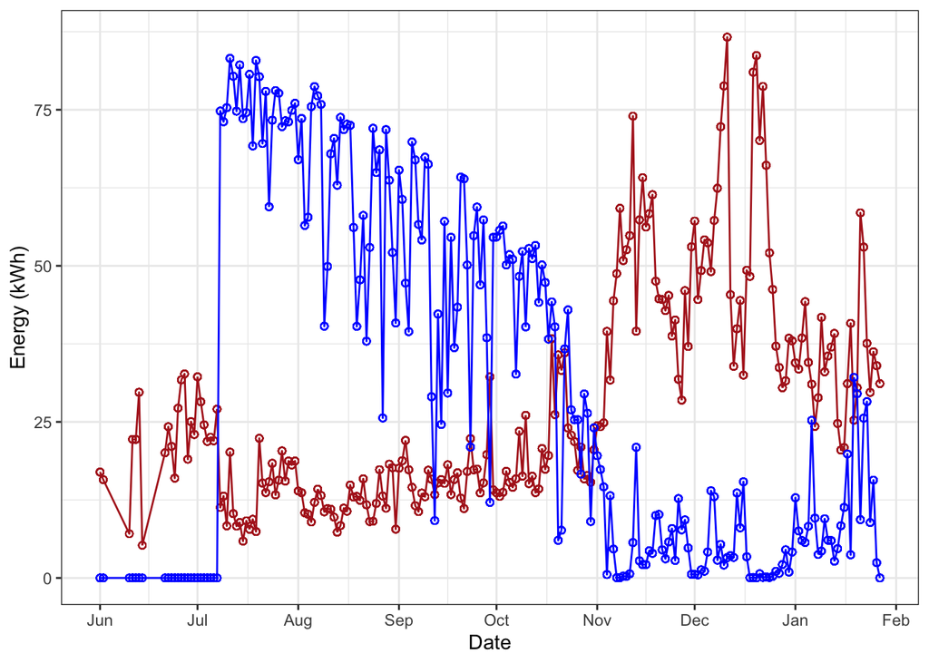

Figure 5: Daily energy consumption (red) and solar production (blue) for our house (kWh), starting June 1, 2022. The solar system came online July 8.

## Calculate total production and consumption

From July 8th to 2023-01-27 (last day of data), let’s calculate how much:

- gross solar energy we’ve produced
- total solar energy returned to grid
- total energy consumed from grid

```r
all_data %>%
  filter(day >= ymd("2022-07-08")) %>%
  summarise(total_solar_produced = sum(kWh, na.rm = TRUE),
            total_fortis_consumed  = sum(kw_consumed, na.rm = TRUE),
            total_solar_returned = sum(kw_returned, na.rm = TRUE))
```

```
## # A tibble: 1 × 3
##   total_solar_produced total_fortis_consumed total_solar_returned
##                  <dbl>                 <dbl>                <dbl>
## 1                6953.                 5762.                4474.
```

Do the same for when we started net metering (July 15)

```r
all_data %>%
  filter(day >= ymd("2022-07-15")) %>%
  summarise(total_solar_produced = sum(kWh, na.rm = TRUE),
            total_fortis_consumed  = sum(kw_consumed, na.rm = TRUE),
            total_solar_returned = sum(kw_returned, na.rm = TRUE))
```

```
## # A tibble: 1 × 3
##   total_solar_produced total_fortis_consumed total_solar_returned
##                  <dbl>                 <dbl>                <dbl>
## 1                6409.                 5682.                4474.
```

## Check bill numbers

Let’s check the data reported on the bill for July 28th through September 28, 2022.

According to the Fortis bill, we consumed 875 kWh from the grid over that 62 days, and we delivered 2674 kWh back to the grid over that same period.

Using the data downloaded from our solar system and the hourly consumption data downloaded directly from the Fortis website, we get the following numbers:

```
## # A tibble: 1 × 2
##   total_consumed total_returned
##            <dbl>          <dbl>
## 1           887.          2703.
```

So, a little off, but not too bad.

Now let’s check Sept 28 to Nov 28, which shows 1929 kWh consumed, and 921 kWh returned.

```
## # A tibble: 1 × 2
##   total_consumed total_returned
##            <dbl>          <dbl>
## 1          1975.           922.
```

Not far off again!

Updates will come as I attempt to get better historical data, and as we progress through the cloudy winter!